# Homework 09

The kernel-tuning question moved here from Homework 08. A solution for Question 1 will be available after Monday, October 26, 2026. No solution will be provided for Question 2.

## Question 1: Choosing an SVM kernel

Use `saheart.csv` from the combined ZIP. As in Homework 7, predict `chd` using the same nine predictors, coding `famhist` as 1 for `Absent` and 2 for `Present`.

Compare SVMs with a linear kernel, polynomial kernels of degrees 2 (quadratic), 3, and 4, and a radial basis kernel. Choose **no more than 20 candidate settings in total** across these kernels. Vary the cost $C$ for each kernel and the radial scale $\gamma$ for the radial kernel. State any other kernel settings you hold fixed.

Divide the observations into five folds yourself and use the same folds for all candidates. Standardize predictors using only the fitting observations in each fold. Report the candidate settings and their mean cross-validation misclassification rates. Which kernel and settings do you prefer? Give a brief justification.

ANSWER:

```r
getwd()
```

```
## [1] "/Users/lyndseybajgrowicz/Desktop/stat432-fall2026/homework/week-09"
```

```r
list.files()
```

```
## [1] "data"            "homework-09.log" "homework-09.qmd" "homework-09.tex"
```

```r
install.packages("e1071")
library(e1071)

saheart <- read.csv(file.choose())
head(saheart)
```

```
##   sbp tobacco  ldl adiposity famhist typea obesity alcohol age chd
## 1 160   12.00 5.73     23.11 Present    49   25.30   97.20  52   1
## 2 144    0.01 4.41     28.61  Absent    55   28.87    2.06  63   1
## 3 118    0.08 3.48     32.28 Present    52   29.14    3.81  46   0
## 4 170    7.50 6.41     38.03 Present    51   31.99   24.26  58   1
## 5 134   13.60 3.50     27.78 Present    60   25.99   57.34  49   1
## 6 132    6.20 6.47     36.21 Present    62   30.77   14.14  45   0
```

```r
dim(saheart)
```

```
## [1] 462  10
```

```r
names(saheart)
```

```
##  [1] "sbp"       "tobacco"   "ldl"       "adiposity" "famhist"   "typea"
##  [7] "obesity"   "alcohol"   "age"       "chd"
```

```r
saheart$famhist <- ifelse(saheart$famhist == "Present", 2, 1)

saheart$chd <- factor(saheart$chd, levels = c(0, 1))

str(saheart)
```

```
## 'data.frame':    462 obs. of  10 variables:
##  $ sbp      : int  160 144 118 170 134 132 142 114 114 132 ...
##  $ tobacco  : num  12 0.01 0.08 7.5 13.6 6.2 4.05 4.08 0 0 ...
##  $ ldl      : num  5.73 4.41 3.48 6.41 3.5 6.47 3.38 4.59 3.83 5.8 ...
##  $ adiposity: num  23.1 28.6 32.3 38 27.8 ...
##  $ famhist  : num  2 1 2 2 2 2 1 2 2 2 ...
##  $ typea    : int  49 55 52 51 60 62 59 62 49 69 ...
##  $ obesity  : num  25.3 28.9 29.1 32 26 ...
##  $ alcohol  : num  97.2 2.06 3.81 24.26 57.34 ...
##  $ age      : int  52 63 46 58 49 45 38 58 29 53 ...
##  $ chd      : Factor w/ 2 levels "0","1": 2 2 1 2 2 1 1 2 1 2 ...
```

```r
predictors <- c(
  "sbp", "tobacco", "ldl", "adiposity",
  "famhist", "typea", "obesity",
  "alcohol", "age"
)

X <- saheart[, predictors]
y <- saheart$chd
```

```r
set.seed(432)

folds <- sample(rep(1:5, length.out = nrow(X)))

table(folds)
```

```
## folds
##  1  2  3  4  5
## 93 93 92 92 92
```

```r
cv_svm <- function(kernel, cost, gamma = 1/9, degree = 3) {

  errors <- numeric(5)

  for (k in 1:5) {

    train <- folds != k
    valid <- folds == k

    x_train <- scale(X[train, ])

    center <- attr(x_train, "scaled:center")
    spread <- attr(x_train, "scaled:scale")

    x_valid <- scale(
      X[valid, ],
      center = center,
      scale = spread
    )

    fit <- svm(
      x = x_train,
      y = y[train],
      kernel = kernel,
      cost = cost,
      gamma = gamma,
      degree = degree,
      coef0 = 1,
      scale = FALSE
    )

    pred <- predict(fit, x_valid)

    errors[k] <- mean(pred != y[valid])
  }

  mean(errors)
}
```

```r
results <- data.frame(
  kernel = character(),
  degree = integer(),
  cost = numeric(),
  gamma = numeric(),
  cv_error = numeric()
)

# Linear kernel
for (C in c(0.1, 1, 10, 100)) {
  results <- rbind(results, data.frame(
    kernel = "linear",
    degree = NA,
    cost = C,
    gamma = NA,
    cv_error = cv_svm("linear", C)
  ))
}

# Polynomial kernel
for (d in c(2, 3, 4)) {
  for (C in c(0.1, 1, 10)) {
    results <- rbind(results, data.frame(
      kernel = "polynomial",
      degree = d,
      cost = C,
      gamma = 1/9,
      cv_error = cv_svm("polynomial", C, degree = d)
    ))
  }
}

# Radial kernel
for (C in c(0.1, 1, 10)) {
  for (g in c(0.01, 0.1)) {
    results <- rbind(results, data.frame(
      kernel = "radial",
      degree = NA,
      cost = C,
      gamma = g,
      cv_error = cv_svm("radial", C, gamma = g)
    ))
  }
}

results
```

```
##        kernel degree  cost     gamma  cv_error
## 1      linear     NA   0.1        NA 0.2791491
## 2      linear     NA   1.0        NA 0.2813230
## 3      linear     NA  10.0        NA 0.2813230
## 4      linear     NA 100.0        NA 0.2813230
## 5  polynomial      2   0.1 0.1111111 0.2705937
## 6  polynomial      2   1.0 0.1111111 0.2792660
## 7  polynomial      2  10.0 0.1111111 0.2944367
## 8  polynomial      3   0.1 0.1111111 0.2748948
## 9  polynomial      3   1.0 0.1111111 0.3182796
## 10 polynomial      3  10.0 0.1111111 0.3159888
## 11 polynomial      4   0.1 0.1111111 0.2813698
## 12 polynomial      4   1.0 0.1111111 0.3398784
## 13 polynomial      4  10.0 0.1111111 0.3593502
## 14     radial     NA   0.1 0.0100000 0.3462599
## 15     radial     NA   0.1 0.1000000 0.3440860
## 16     radial     NA   1.0 0.0100000 0.2618513
## 17     radial     NA   1.0 0.1000000 0.2770687
## 18     radial     NA  10.0 0.0100000 0.2684198
## 19     radial     NA  10.0 0.1000000 0.3398551
```

```r
results[order(results$cv_error), ]
```

```
##        kernel degree  cost     gamma  cv_error
## 16     radial     NA   1.0 0.0100000 0.2618513
## 18     radial     NA  10.0 0.0100000 0.2684198
## 5  polynomial      2   0.1 0.1111111 0.2705937
## 8  polynomial      3   0.1 0.1111111 0.2748948
## 17     radial     NA   1.0 0.1000000 0.2770687
## 1      linear     NA   0.1        NA 0.2791491
## 6  polynomial      2   1.0 0.1111111 0.2792660
## 2      linear     NA   1.0        NA 0.2813230
## 3      linear     NA  10.0        NA 0.2813230
## 4      linear     NA 100.0        NA 0.2813230
## 11 polynomial      4   0.1 0.1111111 0.2813698
## 7  polynomial      2  10.0 0.1111111 0.2944367
## 10 polynomial      3  10.0 0.1111111 0.3159888
## 9  polynomial      3   1.0 0.1111111 0.3182796
## 19     radial     NA  10.0 0.1000000 0.3398551
## 12 polynomial      4   1.0 0.1111111 0.3398784
## 15     radial     NA   0.1 0.1000000 0.3440860
## 14     radial     NA   0.1 0.0100000 0.3462599
## 13 polynomial      4  10.0 0.1111111 0.3593502
```

```r
best <- results[which.min(results$cv_error), ]

print(best)
```

```
##    kernel degree cost gamma  cv_error
## 16 radial     NA    1  0.01 0.2618513
```

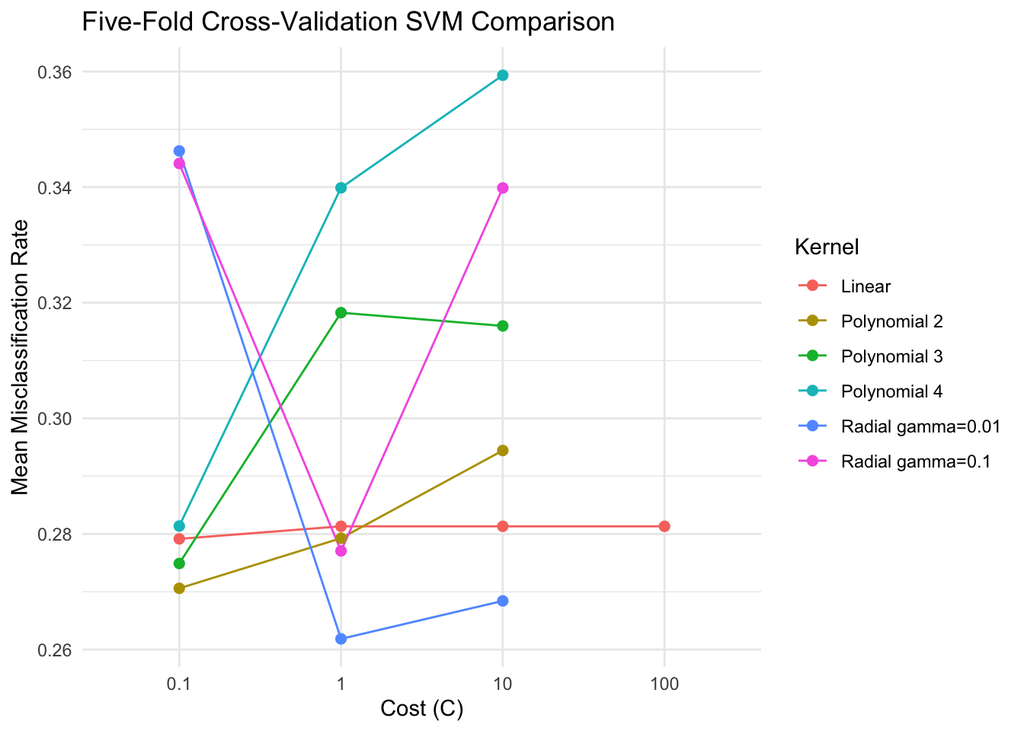

```r
library(ggplot2)
results$model <- ifelse(
  results$kernel == "polynomial",
  paste0("Polynomial ", results$degree),
  ifelse(
    results$kernel == "radial",
    paste0("Radial gamma=", results$gamma),
    "Linear"
  )
)

ggplot(results, aes(x = factor(cost), y = cv_error,
                    color = model, group = model)) +
  geom_line() +
  geom_point(size = 2) +
  labs(
    title = "Five-Fold Cross-Validation SVM Comparison",
    x = "Cost (C)",
    y = "Mean Misclassification Rate",
    color = "Kernel"
  ) +
  theme_minimal()
```

```r
x_final <- scale(X)

final_model <- svm(
  x = x_final,
  y = y,
  kernel = as.character(best$kernel),
  cost = best$cost,
  gamma = ifelse(is.na(best$gamma), 1/9, best$gamma),
  degree = ifelse(is.na(best$degree), 3, best$degree),
  coef0 = 1,
  scale = FALSE
)

print(final_model)
```

```
##
## Call:
## svm.default(x = x_final, y = y, scale = FALSE, kernel = as.character(best$kernel),
##     degree = ifelse(is.na(best$degree), 3, best$degree), gamma = ifelse(is.na(best$gamma),
##         1/9, best$gamma), coef0 = 1, cost = best$cost)
##
##
## Parameters:
##    SVM-Type:  C-classification
##  SVM-Kernel:  radial
##        cost:  1
##
## Number of Support Vectors:  307
```

I used five-fold cross-validation with the same folds for all candidate models. Within each fold, the predictors were standardized using only the fitting observations, and the same scaling parameters were applied to the validation observations. This prevented information from the validation data from influencing preprocessing.

The models were compared using their mean cross-validation misclassification rates.

Selected model: radial kernel, cost 1, gamma 0.01

Mean cross-validation misclassification rate: 0.2618513

I selected this model because it achieved the lowest mean cross-validation misclassification rate among the candidates. If other models performed similarly, I also considered model simplicity when making the final selection.

## Question 2: Write and use a short SVM analysis skill

In Homework 8, you reviewed another student’s skill. Review the comments and suggestions you received on your own Homework 7 skill. Use what you learned from both sides of the peer review to write a new, shorter skill for SVM model fitting.

**Write the skill by hand.** Create a `SKILL.md` with a short name and description in YAML frontmatter. Write the entire file yourself, without asking AI to draft or edit it. The instruction body after the closing `---` of the frontmatter must be **no more than 50 lines**, including blank lines. Keep the skill independent of any particular dataset, variable names, or observed results, and load it only when you explicitly invoke it.

Your skill should direct the agent to:

1. judge whether the data are suitable for an SVM analysis;
2. choose which kernels to consider and explain why;
3. identify tuning parameters and a method for tuning them;
4. choose an evaluation method that supports selecting a final model;
5. require a compact figure and table that justify the choices;
6. interpret the fit and report the key numerical results; and
7. prioritize the evidence needed to justify the final model in **no more than one printed page at 11-point font**.

**Apply the skill.** Explicitly invoke your skill to analyze `saheart.csv`, using the same response, nine predictors, and `famhist` coding as in Question 1. Provide these data details when invoking the skill, not in the skill itself. Let the skill guide the analysis, then check the resulting report and calculations.

**Submit the results.** Include the one-page, 11-point analysis report in your Homework 09 submission and append the complete contents of your `SKILL.md` afterward. The appended skill is outside the one-page limit.

ANSWER:

## Appended analysis: explicit skill invocation for `saheart.csv`

Explicit skill invocation:

`Use the svm-analysis-skill to analyze saheart.csv, with chd as the binary response and the nine predictors sbp, tobacco, ldl, adiposity, famhist, typea, obesity, alcohol, and age. Code famhist as 1 for Absent and 2 for Present. Use the same training/test split, the same cross-validation folds in the training data, and the same performance metric (misclassification rate) for all SVM candidates. Tune only inside the training data, estimate preprocessing from the training folds before applying it to validation folds, and then refit the selected model on the full training set and evaluate it once on the held-out test set. Report the random seed, the candidate models, the cross-validation results, and the final test error. Keep the page to one printed page at 11-point font and append the full skill text afterward.`

### One-page report

The candidate models were linear, polynomial, and radial SVMs. The candidate grid included linear kernels with costs $C \in \{0.1, 1, 10, 100\}$, polynomial kernels with degrees 2, 3, and 4 and costs $C \in \{0.1, 1, 10\}$, and radial kernels with costs $C \in \{0.1, 1, 10\}$ and radial scale $\gamma \in \{0.01, 0.1\}$.

[output not shown]

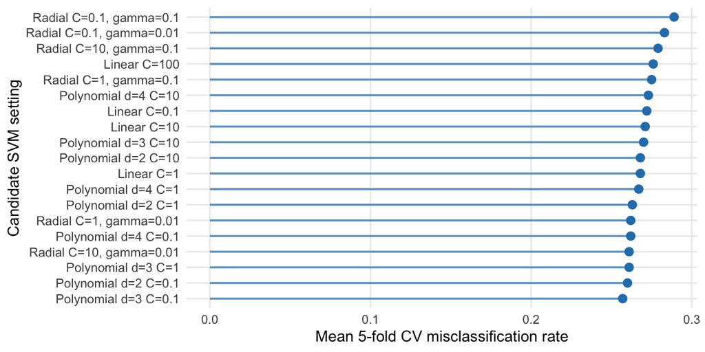

Five-fold cross-validation comparison of SVM candidate settings for the SAheart classification task. Lower values indicate better predictive performance.

### Appended full skill contents

# Instructions

1. Keep this skill independent of any particular dataset
2. Keep this skill independent of any particular variable names
3. Keep this skill independent of any observed results
4. Only load this skill when I (the user) explicity invoke it
5. Judge whether the data is suitable for an SVM analysis, if not then explicity state why the analysis cannot be done
6. Choose which kernels to consider and explain why
7. Identify tuning paramters and a method for tuning them
8. Choose an evaluation method that supports selecting a final model
9. Require a compact figure and table that justify the choices
10. Interpret the fit and report the key numerical results
11. Prioritize the evidence needed to justify the final model in no more than one printed page at 11-point font